# R Notebook

#Manual model development

### Section 1: MVP

**Tidy up the data ready for regression:**

```r
library(tidyverse)
library(janitor)
library(modelr)
library(broom)
library(ggfortify)
library(infer)
library(fastDummies)
library(mosaicData)

# visualisation packages
library(ggiraphExtra)
library(GGally)
```

The **kc_house_data** dataset from Kaggle page is considered for this study. This dataset contains house sale prices for King County, Seattle. It includes homes sold between May 2014 and May 2015. The aim of the study is to build a regression model for the sold house **price** variable with respect to some predictor variables in the dataset.

```r
house_data <- read_csv("data/kc_house_data.csv")
glimpse(house_data)
```

[output not shown]

The dataset contains 21 variables. Some variables are dropped from the dataset as we are confident enough to say they are not significant for the regression model. For example, the home **id** and **date** variables are not needed in the study. Moreover, the number of bathrooms, and longitude and latitude variables are expected also to be less significant. However, they will remain in dataset for furter analysis.

The remaining predictor variables are now grouped into three categories. For each category, a **ggpairs( )** plot will be used to examined if they is any correlation between the **price** and predictor variables from each category. The categories are given below by: 1. Condition of the house

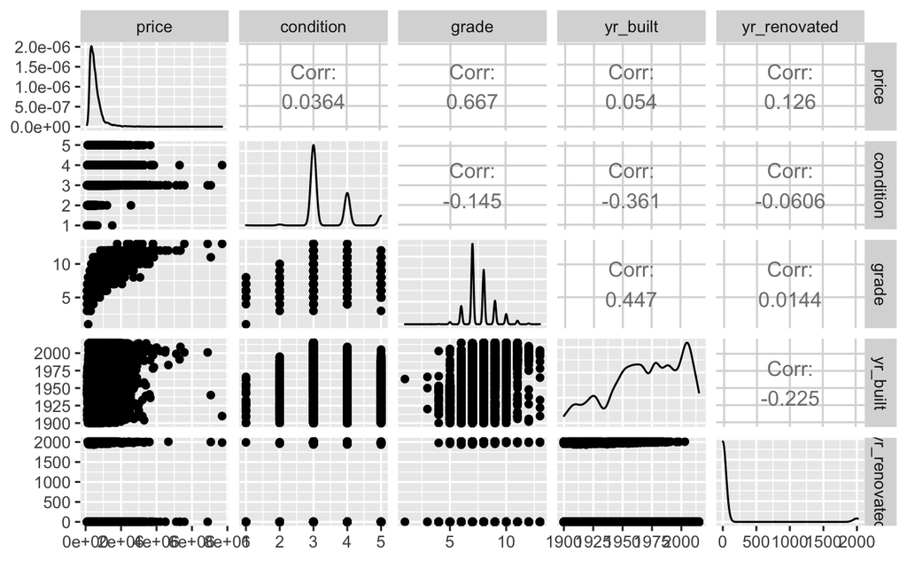

2. Area of the house

[figure not shown]

3. Neighbourhood

```r
ggpairs(house_data[,c("price","lat", "long", "zipcode", "sqft_living15", "sqft_lot15", "waterfront", "view")])
```

[output not shown]

After looking the above plots, the following 11 predictor variables will remain in the study for further analysis: 1. sqft_living (r = 0.702) 2. grade (r = 0.667) 3. sqft_above (r = 0.606) 4. bathrooms (r = 0.525) 5. view (r = 0.397) 6. sqft_basement (r = 0.324) 7. bedrooms (r = 0.308) 8. lat (r = 0.307) 9. watefront (r = 0.266) 10. floors (r = 0.257) 11. yr_renovated (r = 0.126)

Let’s now built our model. We start with **sqft_living**

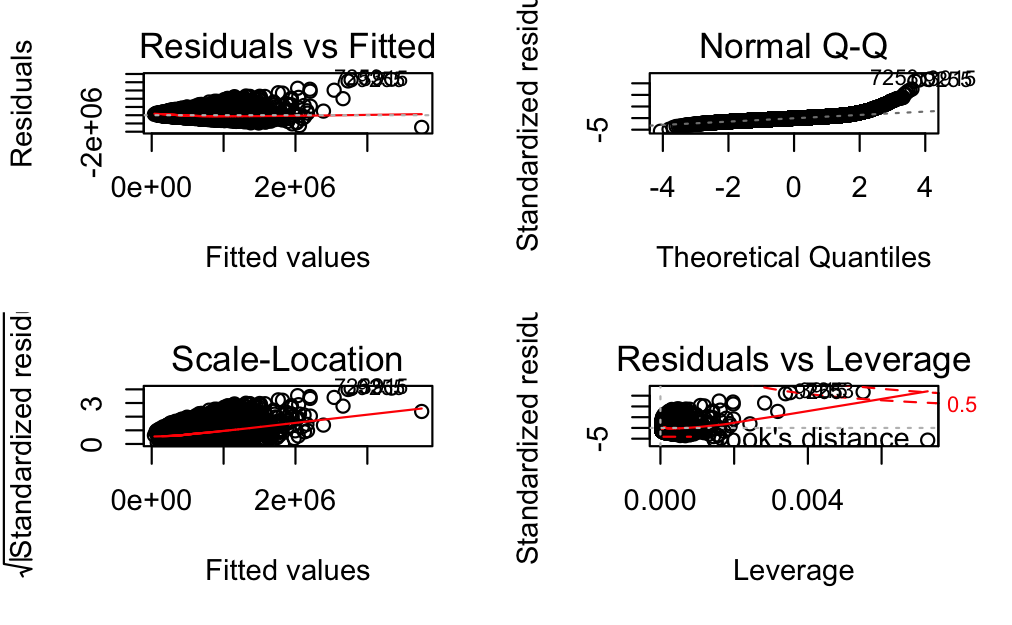

We now need a second predictor for our model.

```r
model2 <- lm(price ~ sqft_living + grade, data = house_data_tidy)
summary(model2)
```

```
Call:
lm(formula = price ~ sqft_living + grade, data = house_data_tidy)

Residuals:
     Min       1Q   Median       3Q      Max
-1065457  -138304   -25043   100447  4794633

Coefficients:
              Estimate Std. Error t value Pr(>|t|)
(Intercept) -5.981e+05  1.330e+04  -44.98   <2e-16 ***
sqft_living  1.844e+02  2.869e+00   64.29   <2e-16 ***
grade        9.855e+04  2.241e+03   43.97   <2e-16 ***
---
Signif. codes:
0 ‘***’ 0.001 ‘**’ 0.01 ‘*’ 0.05 ‘.’ 0.1 ‘ ’ 1

Residual standard error: 250500 on 21610 degrees of freedom
Multiple R-squared:  0.5345,    Adjusted R-squared:  0.5345
F-statistic: 1.241e+04 on 2 and 21610 DF,  p-value: < 2.2e-16
```

And add a third predictor for our model.

```r
model3 <- lm(price ~ sqft_living + grade + view, data = house_data_tidy)
summary(model3)
```

```
Call:
lm(formula = price ~ sqft_living + grade + view, data = house_data_tidy)

Residuals:
     Min       1Q   Median       3Q      Max
-1251382  -129449   -20575    97552  4732904

Coefficients:
              Estimate Std. Error t value Pr(>|t|)
(Intercept) -543450.45   12804.04  -42.44   <2e-16 ***
sqft_living     166.32       2.78   59.84   <2e-16 ***
grade         93344.46    2151.14   43.39   <2e-16 ***
view          97615.51    2226.10   43.85   <2e-16 ***
---
Signif. codes:
0 ‘***’ 0.001 ‘**’ 0.01 ‘*’ 0.05 ‘.’ 0.1 ‘ ’ 1

Residual standard error: 240000 on 21609 degrees of freedom
Multiple R-squared:  0.5725,    Adjusted R-squared:  0.5725
F-statistic:  9648 on 3 and 21609 DF,  p-value: < 2.2e-16
```